# Scalability of bayesianVARs

Luis Gruber

```r
library(bayesianVARs)
```

**This vignette only deals with the computational complexity of the implemented algorithms. It does not cover sampling efficiency in terms of mixing.**

bayesianVARs’ `bvar()` implements state of the art Markov Chain Monte Carlo (MCMC) algorithms for posterior estimation of Bayesian vectorautoregressions (VARs). The computational complexity of those algorithms depends on the configuration of the error variance-covariance matrix which is specified through the function argument `prior_sigma`. This argument expects a `bayesianVARs_prior_sigma` object which can be conveniently created using the helper function `specify_prior_sigma()`.

## Factor specification

The factor structure on the errors is achieved by setting `specify_prior_sigma()`’s argument `type = "factor"`. The following code snippet is a minimal working example of estimating a VAR featuring stochastic volatility with a factor structure on the errors.

```r
set.seed(321)
# Simulate data
n <- 50L # number of observations
M <- 3L # number of time series
Y <- matrix(rnorm(n*M), n, M)
colnames(Y) <- paste0("y", 1:M)
# Estimate a VAR with a factor structure on the errors
prior_sigma_f <- specify_prior_sigma(Y, type = "factor")
mod_f1 <- bvar(Y, draws = 50L, burnin = 5L, prior_sigma = prior_sigma_f,
            quiet = TRUE)
```

For the factor specification bayesianVARs implements the conditional equation per equation algorithm described in Kastner and Huber (2020). Using default settings, **this algorithm is of complexity *O*(*M*<sup>4</sup>*p*<sup>3</sup>)**, where *M* is the number of time series and *p* the number of lags.

## Factor specifcation in huge dimensions

In the aforementioned paper it is also demonstrated that for VARs in huge dimensions, within the conditional equation per equation algorithm, the algorithm of Bhattacharya, Chakraborty, and Mallick (2016) for sampling from high-dimensional Gaussian distributions can be exploited to further speed up computations. This feature is invoked by setting `bvar()`’s argument `expert_huge = TRUE`.

```r
mod_f2 <- bvar(Y, draws = 50L, burnin = 5L, prior_sigma = prior_sigma_f,
               expert_huge = TRUE, quiet = TRUE)
```

Using this sampler-configuration, **the algorithm is of complexity *O*(*p**M*<sup>2</sup>*n*<sup>2</sup>)**, where *n* is the number of observations. Therefore, it can be expected that setting `expert_huge = TRUE` **only speeds up computations in scenarios where *p**M* > *n***, i.e. the number of VAR coefficients per equations exceeds the number of observations.

## Cholesky specification

The Cholesky structure on the errors is achieved by setting `specify_prior_sigma()`’s argument `type = "cholesky"`. The following code snippet is a minimal working example of estimating a VAR featuring stochastic volatility with a Cholesky structure on the errors.

```r
# Estimate a VAR with a Cholesky structure on the errors
prior_sigma_c <- specify_prior_sigma(Y, type = "cholesky")
mod_c <- bvar(Y, draws = 50L, burnin = 5L, prior_sigma = prior_sigma_c,
            quiet = TRUE)
```

For the Cholesky specification bayesianVARs implements the correct triangular algorithm described in Carriero et al. (2022). **This algorithm is of complexity *O*(*M*<sup>4</sup>*p*<sup>3</sup>)**, i.e. it has the same complexity like the standard conditional equation per equation algorithm for the factor specification, see Factor specification.

## Empirical demonstration

The following code chunk runs the posterior sampling algorithm and records computation times for all sampling algorithms considering all combinations of *M* = 50, *n* = 100, *s**t**o**c**h**a**s**t**i**c* *v**o**l**a**t**i**l**i**t**y* ∈ {*T**R**U**E*, *F**A**L**S**E*}, and *p* ∈ {1, …, 5}.

```r
set.seed(123)
ps <- 1:5 # lags
M <- 50L # number time series
n <- 100L # number of observations for estimation
factors <- c(1L,50L) # number of factors
huge <- c(FALSE, TRUE) # expert_huge algorithm
svs <- c(FALSE, TRUE) # stochastic volatility
factor_combinations <- expand.grid(p = ps, M = M, n = n, r = factors,
                                expert_huge = huge, sv = svs, type = "factor",
                                stringsAsFactors = FALSE)
cholesky_combinations <- expand.grid(p = ps, M = M, n = n, r = 0,
                                expert_huge = FALSE, sv = svs, type = "cholesky",
                                stringsAsFactors = FALSE)
all_combinations <- rbind(factor_combinations, cholesky_combinations)
Tobs <- all_combinations$n + all_combinations$p # number of total observations
all_combinations <- cbind(all_combinations, Tobs = Tobs, user_time = as.numeric(NA))
for(i in seq_len(nrow(all_combinations))){
  p <- all_combinations$p[i]
  M <- all_combinations$M[i]
  Tob <- all_combinations$Tobs[i]
  r <- all_combinations$r[i]
  expert_huge <- all_combinations$expert_huge[i]
  type <- all_combinations$type[i]
  sv <- all_combinations$sv[i]

  # simulate data
  Y <- matrix(rnorm(Tob*M), Tob, M)
  colnames(Y) <- paste0("y", 1:M)
  # prior configuration
  prior_sigma <- specify_prior_sigma(data = Y, type = type, factor_factors = r,
                                     factor_heteroskedastic = sv,
                                     cholesky_heteroscedastic = sv,
                                     quiet = TRUE)
  # generate posterior draws
  res <- bvar(Y, lags = p, draws = 10L, burnin = 0L,
                            prior_intercept = FALSE,
                            prior_sigma = prior_sigma,
       expert_huge = expert_huge, quiet = TRUE)
  # store user time
  all_combinations$user_time[i] <- res[["bench"]]["user.self"]
}
```

**The estimates of computation time are based on an Intel**<sup>®</sup> **Core**<sup>™</sup> **i7-10610U processor using one core in combination with a standard single-threaded R installation**.

Figure 1, which can be replicated with the following code chunk, depicts the computation time of generating 10 draws from the joint posterior distribution of all parameters and latent variables. Interestingly, the additional cost when moving from a homoscedastic model (constant error variance-covariance matrix) to a heteroscedastic model (time varying error variance-covariance matrix featuring stochastic volatility), or in case of the factor specification when moving from a model with 1 factor to a model with 50 factors, appears to be negligible.

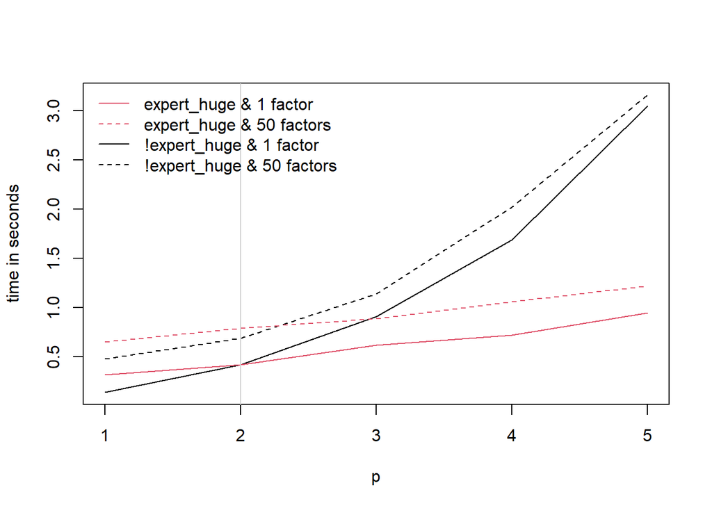

(a) Factor stochastic volatility specification

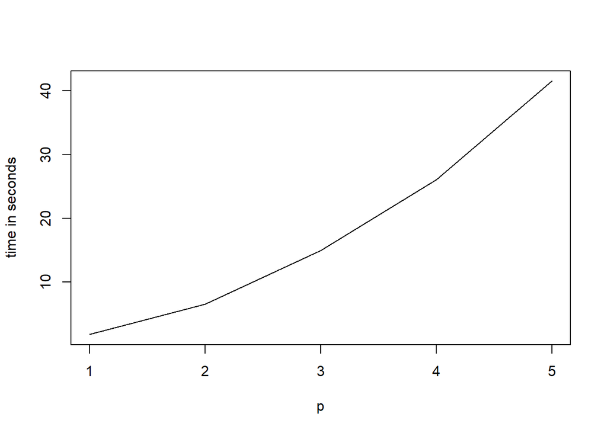

(b) Cholesky stochastic volatility specification

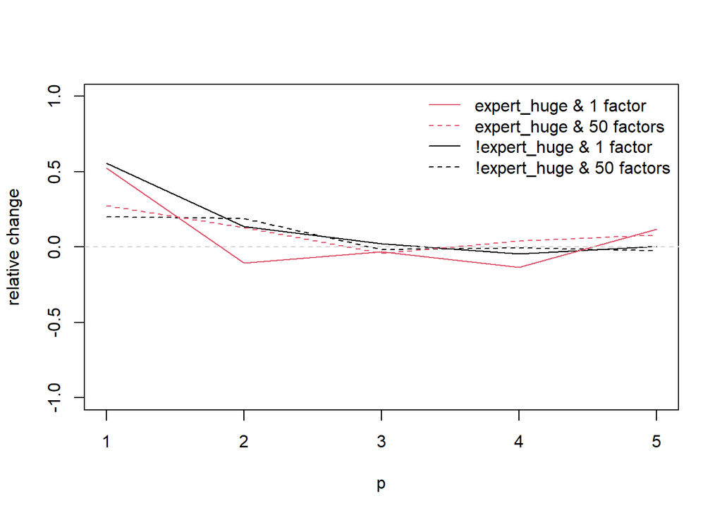

(c) Factor specification: Relative change when moving from homoscedasticity to heteroscdedasticity

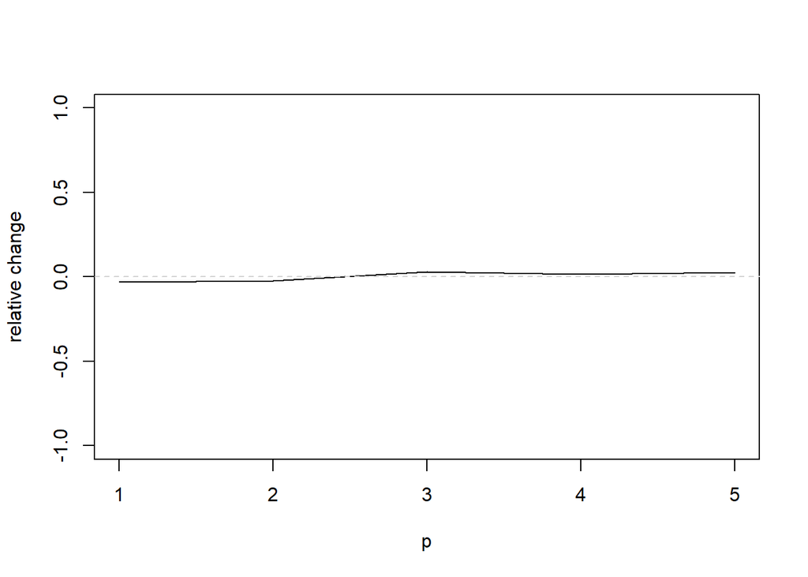

(d) Cholesky specification: Relative change when moving from homoscedasticity to heteroscdedasticity

Figure 1: Computing times for generating 10 draws from the joint posterior distribution of all parameters and latent variables. The grey vertical line in the top left plot indicates the scenario where ‘expert_huge’ and ‘!expert_huge’ are expected to have more or less equal running times. The plots in the bottom panel depict the relative change when moving from a homoscedastic VAR (constant error variance-covariance matrix w.r.t. time) to a heteroscedastic VAR (time varying error variance-covariance matrix featuring stochastic volatility).

```r
for(type0 in c("factor", "cholesky")){
  tmp <- subset(all_combinations, type == type0 & sv == TRUE)
  plot(0,0, xlim = range(tmp$p), ylim = range(tmp$user_time),
     type="n", xlab = "p", ylab = "time in seconds")
    if(type0=="cholesky"){
      lines(tmp$p,
          tmp$user_time)
    }else{
      for(expert in huge){
        for(rr in factors){
          lines(with(tmp, subset(p, r == rr & expert_huge == expert & type == "factor")),
          with(tmp, subset(user_time, r == rr & expert_huge == expert & type == "factor")),
          col = expert + 1L, lty = if(rr==1L) 1 else 2)
        }
      }
      abline(v = n/M, col = "lightgrey")
      legend("topleft", legend = c("expert_huge & 1 factor", "expert_huge & 50 factors",
                                   "!expert_huge & 1 factor", "!expert_huge & 50 factors"),
             col = c(2L, 2L, 1L, 1L),
             lty = c(1L, 2L, 1L, 2L), bty="n")
    }
}

for(type0 in c("factor", "cholesky")){
  tmp <- subset(all_combinations, type == type0)
  plot(0,0, xlim = range(tmp$p), ylim = c(-1,1),
     type="n", xlab = "p", ylab = "relative change")
  if(type0 == "cholesky"){
    tmp_sv <- subset(tmp, sv == TRUE)
    tmp_nosv <- subset(tmp, sv == FALSE)
    thediff <- tmp_sv$user_time - tmp_nosv$user_time
    normalizer <- tmp_nosv$user_time
    lines(tmp_sv$p, thediff/normalizer)
  }else{
    for(expert in huge){
      for(rr in factors){
        tmp_sv <- subset(tmp, sv == TRUE & r == rr & expert_huge == expert)
        tmp_nosv <- subset(tmp, sv == FALSE & r == rr & expert_huge == expert)
        thediff <- tmp_sv$user_time - tmp_nosv$user_time
        normalizer <- tmp_nosv$user_time
        lines(tmp_sv$p, thediff/normalizer,
          col = expert + 1L, lty = if(rr==1L) 1 else 2)
      }
    }
    legend("topright", legend = c("expert_huge & 1 factor", "expert_huge & 50 factors",
                                 "!expert_huge & 1 factor", "!expert_huge & 50 factors"),
           col = c(2L, 2L, 1L, 1L),
             lty = c(1L, 2L, 1L, 2L), bty = "n")
  }
  abline(h=0, col = "lightgrey", lty=2)

}
```

## References

Bhattacharya, Anirban, Antik Chakraborty, and Bani K. Mallick. 2016. “Fast Sampling with Gaussian Scale Mixture Priors in High-Dimensional Regression.” *Biometrika* 103 (4): 985–91. https://doi.org/10.1093/biomet/asw042.

Carriero, Andrea, Joshua Chan, Todd E. Clark, and Massimiliano Marcellino. 2022. “Corrigendum to ‘Large Bayesian Vector Autoregressions with Stochastic Volatility and Non-Conjugate Priors’ [j. Econometrics 212 (1) (2019) 137–154].” *Journal of Econometrics* 227 (2): 506–12. https://doi.org/10.1016/j.jeconom.2021.11.010.

Kastner, Gregor, and Florian Huber. 2020. “Sparse Bayesian Vector Autoregressions in Huge Dimensions.” *Journal of Forecasting* 39 (7): 1142--1165. https://doi.org/10.1002/for.2680.